# Exemplos de uso

### Processamento de imagem: utilizando Keras para classificar imagens de objetos

Este é outro exemplo apresentado por Vasilev et al. (2019) em seu livro.

Neste caso, utilizaremos a biblioteca Keras para classificar imagens de objetos.

Keras é uma biblioteca que facilita a criação de redes neurais, mas, também, facilita o acesso aos dados de teste.

Nesta seção, vamos utilizar os dados do CIFAR-10 (Canadian Institute For Advanced Research).

As classes do CIFAR-10 são: aviões, carros, pássaros, gatos, cervos, cachorros, sapos, cavalos, navios, caminhões.

A Figura 14 nos mostra exemplos dessas classes, respectivamente, de cima para baixo.

*Importando bibliotecas para exibir imagem*

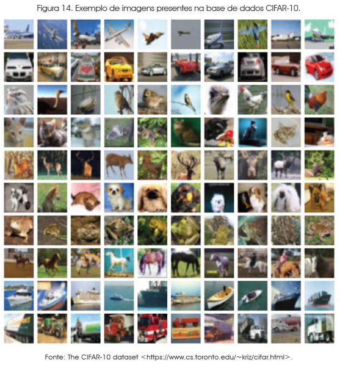

```python
from IPython.display import Image

# Plotando imagem da figura 12
Image("figura14.png")
```

Assim como no MNIST, a base de dados CIFAR-10 é dividida em imagens para treinamento e imagens para teste.

Neste caso, são 50.000 para treinamento e 10.000 para teste.

Inicialmente, vamos importar as imagens do CIFAR-10, assim como fizemos com os dados do MNIST:

*Importando bibliotecas Keras e massa de dados*

```python
from keras.datasets import cifar10
from keras.layers.core import Dense, Activation
from keras.models import Sequential
from keras.utils import np_utils
```

Em seguida, vamos dividir os dados importados em 50.000 imagens para treinamento e 10.000 para teste.

Da mesma forma, vamos remodelar os dados para um vetor unidimensional:

*Carregando dados de teste e treinamento*

```python
(X_train, Y_train), (X_test, Y_test) = cifar10.load_data()

X_train = X_train.reshape(50000, 3072)
X_test = X_test.reshape(10000, 3072)

classes = 10
Y_train = np_utils.to_categorical(Y_train, classes)
Y_test = np_utils.to_categorical(Y_test, classes)

input_size = 3072
batch_size = 100
epochs = 100
```

Note que os dados disponibilizados pelo CIFAR-10 são mais complexos que os dados do MNIST, dessa forma, a rede deve refletir essa complexidade.

Por este motivo, usaremos três camadas de neurônios ocultos para esse experimento, também usaremos mais neurônios:

*Definindo 3 camadas ocultas com função de ativação relu, sigmoid com softmax*

```python
model = Sequential([
    Dense(1024, input_dim=input_size),
    Activation('relu'),
    Dense(512),
    Activation('relu'),
    Dense(512),
    Activation('sigmoid'),
    Dense(classes),
    Activation('softmax')
])
```

Efetuaremos o treinamento da rede com mais um parâmetro, o validation_ data=(X_test, Y_test), este comando fará com que a rede utilize os dados de teste para validação da rede:

*Compilando o modelo com otimização em SGD e treinando*

```python
model.compile(loss='categorical_crossentropy', metrics=['accuracy'], optimizer='sgd')
model.fit(X_train, Y_train, batch_size=batch_size, epochs=epochs, validation_data=(X_test, Y_test), verbose=1)
```

```
Train on 50000 samples, validate on 10000 samples
```

```
<keras.callbacks.callbacks.History at 0x25e6c8a4a88>
```

Para verificar o que a rede aprendeu, vamos visualizar os pesos dos 100 neurônios da primeira camada.

Lembre-se de é necessário reajustar os pesos para matrizes de tamanho 32x32, calculando a média dos valores presentes nos três canais para gerar uma imagem em tons de cinza (onde a tonalidade é a média entre os valores dos canais R, G e B):

*Plotando resultado*

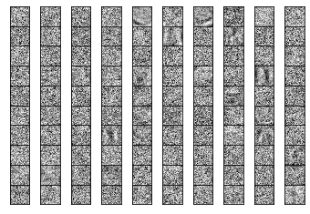

```python
import matplotlib.pyplot as plt
import matplotlib.cm as cm
import matplotlib.gridspec as gridspec
import numpy
import random

fig = plt.figure()
outer_grid = gridspec.GridSpec(10, 10, wspace=0.0, hspace=0.0)

weights = model.layers[0].get_weights()

w = weights[0].T

for i, neuron in enumerate(random.sample(range(0, 1023), 100)):
    ax = plt.Subplot(fig, outer_grid[i])
    ax.imshow(numpy.mean(numpy.reshape(w[i], (32, 32, 3)),axis=2), cmap=cm.Greys_r)
    ax.set_xticks([])
    ax.set_yticks([])
    fig.add_subplot(ax)

plt.show()
```

Foi possível perceber que a fase de treinamento demorou mais do que quando treinamos a rede para classificar os dados do MNIST.

Isso se deu devido à maior complexidade dos dados.